# 20210323-p8158_hw6_jsg2145

Jared Garfinkel

3/23/2021

# read in data

```r
data = read_csv("./data/SEM for uwcb.csv") %>%
  janitor::clean_names()
```

```r
skimr::skim(data)
```

Data summary

| Name | data |
| --- | --- |
| Number of rows | 4746 |
| Number of columns | 20 |
| _______________________ |  |
| Column type frequency: |  |
| character | 19 |
| numeric | 1 |
| ________________________ |  |
| Group variables | None |

**Variable type: character**

| skim_variable | n_missing | complete_rate | min | max | empty | n_unique | whitespace |
| --- | --- | --- | --- | --- | --- | --- | --- |
| id | 0 | 1 | 5 | 5 | 0 | 4746 | 0 |
| gender | 0 | 1 | 1 | 1 | 0 | 3 | 0 |
| diet_yr | 0 | 1 | 1 | 1 | 0 | 6 | 0 |
| enjoy | 0 | 1 | 1 | 1 | 0 | 5 | 0 |
| frndwt | 0 | 1 | 1 | 1 | 0 | 6 | 0 |
| wt_imprt | 0 | 1 | 1 | 1 | 0 | 5 | 0 |
| teasewt | 0 | 1 | 1 | 1 | 0 | 6 | 0 |
| fam_wt | 0 | 1 | 1 | 1 | 0 | 3 | 0 |
| ses_s | 0 | 1 | 1 | 1 | 0 | 6 | 0 |
| famcomm | 0 | 1 | 1 | 2 | 0 | 18 | 0 |
| concrnwt | 0 | 1 | 1 | 2 | 0 | 14 | 0 |
| ben_he | 0 | 1 | 1 | 2 | 0 | 17 | 0 |
| wtconcrn | 0 | 1 | 1 | 2 | 0 | 11 | 0 |
| bodydiss | 0 | 1 | 1 | 2 | 0 | 42 | 0 |
| hlthcncr | 0 | 1 | 1 | 2 | 0 | 17 | 0 |
| depressn | 0 | 1 | 1 | 2 | 0 | 16 | 0 |
| slfestem | 0 | 1 | 1 | 2 | 0 | 20 | 0 |
| uwcb_yr | 0 | 1 | 1 | 1 | 0 | 11 | 0 |
| bmi_sf | 0 | 1 | 1 | 4 | 0 | 280 | 0 |

**Variable type: numeric**

| skim_variable | n_missing | complete_rate | mean | sd | p0 | p25 | p50 | p75 | p100 | hist |
| --- | --- | --- | --- | --- | --- | --- | --- | --- | --- | --- |
| ageyrs | 10 | 1 | 14.86 | 1.69 | 11 | 13 | 15 | 16 | 18 | ▃▅▇▇▃ |

```r
head(data)
```

```
## # A tibble: 6 x 20
##   id    gender diet_yr enjoy frndwt wt_imprt teasewt fam_wt ageyrs ses_s famcomm
##   <chr> <chr>  <chr>   <chr> <chr>  <chr>    <chr>   <chr>   <dbl> <chr> <chr>
## 1 01001 1      1       2     1      2        1       1          12 3     18
## 2 01003 1      2       2     1      4        1       2          11 1     13
## 3 01004 1      1       2     2      2        4       1          12 4     16
## 4 01005 2      1       3     1      1        1       1          12 2     17
## 5 01006 2      2       4     5      .        1       1          12 3     14
## 6 01008 1      1       2     2      2        1       1          12 5     18
## # ... with 9 more variables: concrnwt <chr>, ben_he <chr>, wtconcrn <chr>,
## #   bodydiss <chr>, hlthcncr <chr>, depressn <chr>, slfestem <chr>,
## #   uwcb_yr <chr>, bmi_sf <chr>
```

```r
df = data %>%
  mutate(across(.fns = as.numeric))
```

```r
names(df)
```

```
##  [1] "id"       "gender"   "diet_yr"  "enjoy"    "frndwt"   "wt_imprt"
##  [7] "teasewt"  "fam_wt"   "ageyrs"   "ses_s"    "famcomm"  "concrnwt"
## [13] "ben_he"   "wtconcrn" "bodydiss" "hlthcncr" "depressn" "slfestem"
## [19] "uwcb_yr"  "bmi_sf"
```

# SEM

```r
model1 <- '
  # measurement model
    outuwcb =~ diet_yr + uwcb_yr
    wtteas =~ teasewt + fam_wt

  # correlating the exogenous variables
    wtteas ~~ bmi_sf

  # structural model - direct effects
    outuwcb ~ a*wtteas + b*bodydiss + c*bmi_sf
    bodydiss ~ d*bmi_sf + e*wtteas

  #indirect
    indirect_outuwcb := b * (d+e)

  #total
    total_outuwcb := a+c+b*(d+e)
'
```

```r
model.fit <- sem(model1, data = df, sample.cov=TRUE, missing = "ML")
```

```r
summary(model.fit, standardized = TRUE)
```

```
## lavaan 0.6-7 ended normally after 81 iterations
##
##   Estimator                                         ML
##   Optimization method                           NLMINB
##   Number of free parameters                         22
##
##                                                   Used       Total
##   Number of observations                          4714        4746
##   Number of missing patterns                        32
##
## Model Test User Model:
##
##   Test statistic                                17.419
##   Degrees of freedom                                 5
##   P-value (Chi-square)                           0.004
##
## Parameter Estimates:
##
##   Standard errors                             Standard
##   Information                                 Observed
##   Observed information based on                Hessian
##
## Latent Variables:
##                    Estimate  Std.Err  z-value  P(>|z|)   Std.lv  Std.all
##   outuwcb =~
##     diet_yr           1.000                               0.711    0.733
##     uwcb_yr           1.597    0.053   30.175    0.000    1.135    0.776
##   wtteas =~
##     teasewt           1.000                               0.796    0.658
##     fam_wt            0.303    0.016   18.668    0.000    0.241    0.578
##
## Regressions:
##                    Estimate  Std.Err  z-value  P(>|z|)   Std.lv  Std.all
##   outuwcb ~
##     wtteas     (a)    0.170    0.025    6.843    0.000    0.190    0.190
##     bodydiss   (b)   -0.031    0.002  -19.721    0.000   -0.043   -0.417
##     bmi_sf     (c)    0.015    0.003    5.559    0.000    0.021    0.096
##   bodydiss ~
##     bmi_sf     (d)   -0.336    0.034   -9.845    0.000   -0.336   -0.159
##     wtteas     (e)   -4.986    0.314  -15.871    0.000   -3.968   -0.411
```

[output cut: 17 more lines]

```
## Variances:
##                    Estimate  Std.Err  z-value  P(>|z|)   Std.lv  Std.all
##    .diet_yr           0.435    0.018   24.692    0.000    0.435    0.462
##    .uwcb_yr           0.849    0.042   20.046    0.000    0.849    0.397
##    .teasewt           0.827    0.037   22.136    0.000    0.827    0.566
##    .fam_wt            0.116    0.004   29.736    0.000    0.116    0.666
##    .bodydiss         71.439    1.814   39.387    0.000   71.439    0.765
##     bmi_sf           20.818    0.435   47.877    0.000   20.818    1.000
##    .outuwcb           0.340    0.017   20.472    0.000    0.674    0.674
##     wtteas            0.633    0.042   15.148    0.000    1.000    1.000
##
## Defined Parameters:
##                    Estimate  Std.Err  z-value  P(>|z|)   Std.lv  Std.all
##     indirect_otwcb    0.163    0.011   14.286    0.000    0.186    0.237
##     total_outuwcb     0.348    0.025   13.785    0.000    0.397    0.524
```

# Part 2, Question a

So, the total effects on outuwcb is:

0.17 + -0.031 + 0.015 + 0.010 + 0.155 = .319

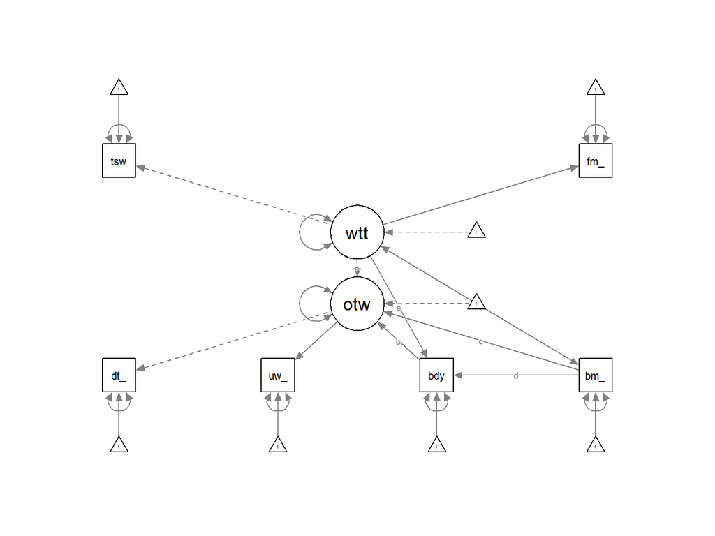

```r
semPaths(model.fit)
```

# Part 2, Question b

```r
model2 <- '
  # measurement model
    outuwcb =~ diet_yr + uwcb_yr
    wtteas =~ teasewt + fam_wt

  # structural model - direct effects
    outuwcb ~ a*wtteas + b*bodydiss + c*bmi_sf
    bodydiss ~ d*bmi_sf + e*wtteas

  #indirect
    indirect_outuwcb := b * (d+e)

  #total
    total_outuwcb := a+c+b*(d+e)
'
```

```r
model.fit2 = sem(model2, data = df, sample.cov=TRUE, missing = "ML")
```

```r
summary(model.fit2, standardized = TRUE)
```

```
## lavaan 0.6-7 ended normally after 67 iterations
##
##   Estimator                                         ML
##   Optimization method                           NLMINB
##   Number of free parameters                         19
##
##                                                   Used       Total
##   Number of observations                          4596        4746
##   Number of missing patterns                        21
##
## Model Test User Model:
##
##   Test statistic                               253.556
##   Degrees of freedom                                 6
##   P-value (Chi-square)                           0.000
##
## Parameter Estimates:
##
##   Standard errors                             Standard
##   Information                                 Observed
##   Observed information based on                Hessian
##
## Latent Variables:
##                    Estimate  Std.Err  z-value  P(>|z|)   Std.lv  Std.all
##   outuwcb =~
##     diet_yr           1.000                               0.700    0.729
##     uwcb_yr           1.595    0.054   29.617    0.000    1.117    0.771
##   wtteas =~
##     teasewt           1.000                               0.783    0.650
##     fam_wt            0.307    0.020   15.282    0.000    0.241    0.579
##
## Regressions:
##                    Estimate  Std.Err  z-value  P(>|z|)   Std.lv  Std.all
##   outuwcb ~
##     wtteas     (a)    0.163    0.024    6.676    0.000    0.183    0.183
##     bodydiss   (b)   -0.031    0.002  -19.618    0.000   -0.044   -0.414
##     bmi_sf     (c)    0.020    0.003    7.633    0.000    0.028    0.128
##   bodydiss ~
##     bmi_sf     (d)   -0.465    0.030  -15.498    0.000   -0.465   -0.224
##     wtteas     (e)   -4.756    0.313  -15.208    0.000   -3.726   -0.393
```

[output cut: 10 more lines]

```
##
## Variances:
##                    Estimate  Std.Err  z-value  P(>|z|)   Std.lv  Std.all
##    .diet_yr           0.433    0.018   24.282    0.000    0.433    0.469
##    .uwcb_yr           0.850    0.043   19.828    0.000    0.850    0.405
##    .teasewt           0.837    0.043   19.312    0.000    0.837    0.577
##    .fam_wt            0.115    0.004   25.777    0.000    0.115    0.665
##    .bodydiss         71.365    1.798   39.686    0.000   71.365    0.795
##    .outuwcb           0.341    0.017   20.186    0.000    0.695    0.695
##     wtteas            0.614    0.047   13.065    0.000    1.000    1.000
##
## Defined Parameters:
##                    Estimate  Std.Err  z-value  P(>|z|)   Std.lv  Std.all
##     indirect_otwcb    0.160    0.012   13.856    0.000    0.183    0.256
##     total_outuwcb     0.343    0.026   13.168    0.000    0.394    0.566
```

So, the total effects on outuwcb are:

0.163+-0.031+0.020+0.014+0.147 = .313

These estimates of total effects are quite close (0.313 vs. 0.319)

The fit statistics are higher than the first model (Chi-squared statistic = 253 > 17.4).

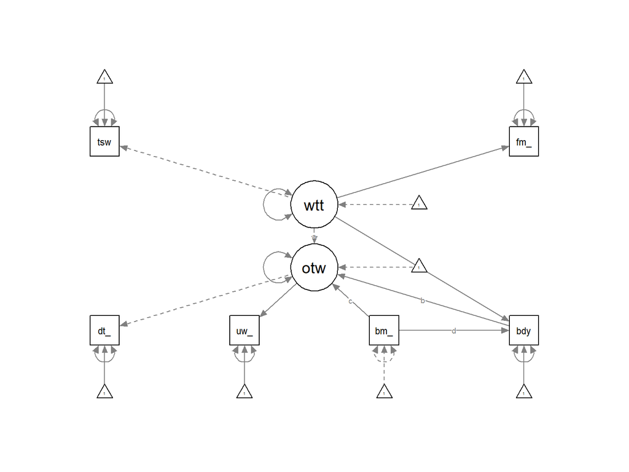

```r
semPaths(model.fit2)
```

# Question 2, part c

```r
model3 <- '
  # structural model - direct effects
    uwcb_yr ~ a*bodydiss + b*teasewt + c*bmi_sf
    diet_yr ~ d*bodydiss+ e*teasewt + f*bmi_sf
    bodydiss ~ g*bmi_sf + h*teasewt
    teasewt ~ j*bmi_sf

  # indirect effects
    ind_uwcb_yr := a*g + a*h + b*j
    ind_diet_yr := d*g + d*h + e*j

  #total effects
    tot_uwcbyr := b*j+c+a*(g+h)
    tot_dietyr := e*j+f+d*(g+h)

  # correlating the exogenous variables
    uwcb_yr ~~ diet_yr
'
```

```r
model.fit3 = lavaan::sem(model3, data = df, sample.cov=TRUE, missing = "ML")
```

```r
summary(model.fit3, standardized = TRUE)
```

```
## lavaan 0.6-7 ended normally after 66 iterations
##
##   Estimator                                         ML
##   Optimization method                           NLMINB
##   Number of free parameters                         18
##
##                                                   Used       Total
##   Number of observations                          4596        4746
##   Number of missing patterns                        14
##
## Model Test User Model:
##
##   Test statistic                                 0.000
##   Degrees of freedom                                 0
##
## Parameter Estimates:
##
##   Standard errors                             Standard
##   Information                                 Observed
##   Observed information based on                Hessian
##
## Regressions:
##                    Estimate  Std.Err  z-value  P(>|z|)   Std.lv  Std.all
##   uwcb_yr ~
##     bodydiss   (a)   -0.055    0.002  -24.433    0.000   -0.055   -0.362
##     teasewt    (b)    0.107    0.018    5.991    0.000    0.107    0.089
##     bmi_sf     (c)    0.024    0.005    5.273    0.000    0.024    0.075
##   diet_yr ~
##     bodydiss   (d)   -0.034    0.002  -22.886    0.000   -0.034   -0.341
##     teasewt    (e)    0.033    0.012    2.770    0.006    0.033    0.041
##     bmi_sf     (f)    0.024    0.003    7.905    0.000    0.024    0.113
##   bodydiss ~
##     bmi_sf     (g)   -0.491    0.030  -16.276    0.000   -0.491   -0.233
##     teasewt    (h)   -2.028    0.116  -17.543    0.000   -2.028   -0.254
##   teasewt ~
##     bmi_sf     (j)    0.054    0.004   13.654    0.000    0.054    0.204
##
## Covariances:
##                    Estimate  Std.Err  z-value  P(>|z|)   Std.lv  Std.all
##  .uwcb_yr ~~
##    .diet_yr           0.561    0.019   28.932    0.000    0.561    0.480
##
## Intercepts:
##                    Estimate  Std.Err  z-value  P(>|z|)   Std.lv  Std.all
##    .uwcb_yr           2.208    0.148   14.916    0.000    2.208    1.513
##    .diet_yr           2.214    0.099   22.374    0.000    2.214    2.290
##    .bodydiss         49.097    0.676   72.645    0.000   49.097    5.107
##    .teasewt           0.599    0.090    6.657    0.000    0.599    0.498
##
## Variances:
##                    Estimate  Std.Err  z-value  P(>|z|)   Std.lv  Std.all
##    .uwcb_yr           1.742    0.037   47.243    0.000    1.742    0.818
##    .diet_yr           0.782    0.016   47.488    0.000    0.782    0.837
##    .bodydiss         79.201    1.692   46.814    0.000   79.201    0.857
##    .teasewt           1.391    0.030   46.617    0.000    1.391    0.958
##
## Defined Parameters:
##                    Estimate  Std.Err  z-value  P(>|z|)   Std.lv  Std.all
##     ind_uwcb_yr       0.144    0.008   17.376    0.000    0.144    0.194
##     ind_diet_yr       0.088    0.005   16.537    0.000    0.088    0.175
##     tot_uwcbyr        0.168    0.009   19.288    0.000    0.168    0.269
##     tot_dietyr        0.112    0.006   19.941    0.000    0.112    0.288
```

The direct effects for uwcb_yr are -0.055 for bodydiss, 0.107 for teaswt, and 0.024 for bmi_sf.

The indirect effects for uwcb_yr are $-0.055*-0.491 + 0.107*0.054$ = 0.032783 for bmi_sf

and, $-0.055*-2.028$ = 0.11154 for teasewt

The total effects are therefore -0.055 + 0.107 + 0.024 + 0.032783 + 0.11154 = 0.221 for uwcb_yr.

The direct effects for diet_yr are -0.034 for bodydiss, 0.033 for teaswt, and 0.024 for bmi_sf.

The indirect effects for diet_yr are $-0.034*-0.491 + 0.033*0.054= 0.018$ for bmi_sf

and, $-0.034*-2.028 = 0.069$ for teasewt

The total effects are therefore -0.034 + 0.033 + 0.024 + 0.018 + 0.069 = .110 for diet_yr.

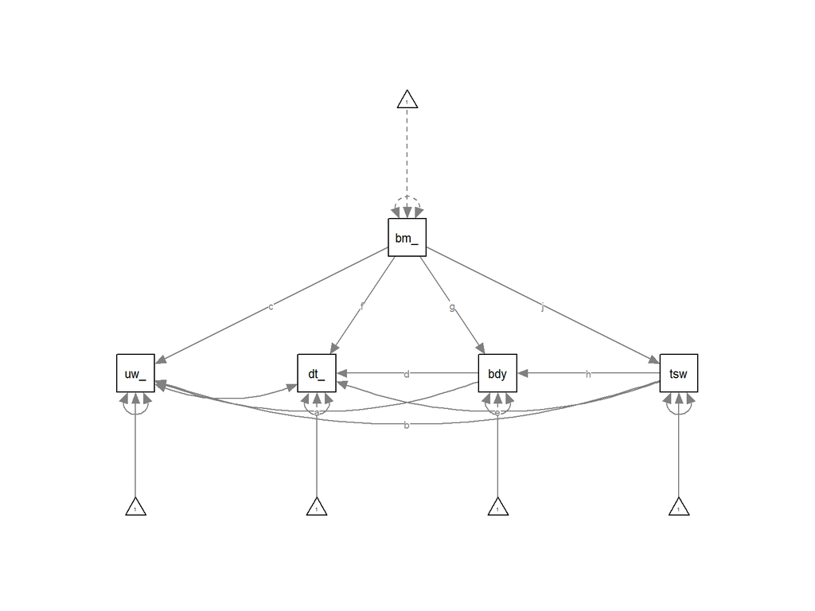

```r
semPaths(model.fit3)
```

```r
fitmeasures(model.fit3, "df")
```

```
## df
##  0
```

```r
fitmeasures(model.fit3, "chisq")
```

```
## chisq
##     0
```

This test is different than that in part b since there are no latent variables. There are no degrees of freedom and no test statistics. It is essentially a linear regression.